# Portfolio metrics and watershed characteristics

M. Snyder

Mar. 17, 2021

### All watersheds

Three populations have no HighCritHab_m. While HighCritHab_m had the highest correlation (0.62) with mean spawner abundance, it isn’t a great measure of watershed size for the populations with 0 values. The second highest correlation was with TotalLength_m (0.54), which is also from the NMFS critical habitat layer. I drop variables indicating watershed size from analysis (-HighCritHab_m, -HighCritHab_p, -HighIP_m, -Watershed_sqkm, -HighIP_p). Use meters of critical habitat as the variable representing watershed size (TotalLength_m). See file:///L:/Priv/CORFiles/Projects/ACE_CIVA_2.8/Marcia/R_code/OCC_Abundance_Size_Metrics.html for details.

Since, TotalLength_m is representing watershed size, the other variables are in terms of percent of the watershed area or length rather than area or length.

Before doing the PCA, I scale the variables by subtracting the mean and dividing by the standard deviation rather than adding one and taking the log as Griffiths et al. 2014 did because negative numbers can’t be logged.

## PCA

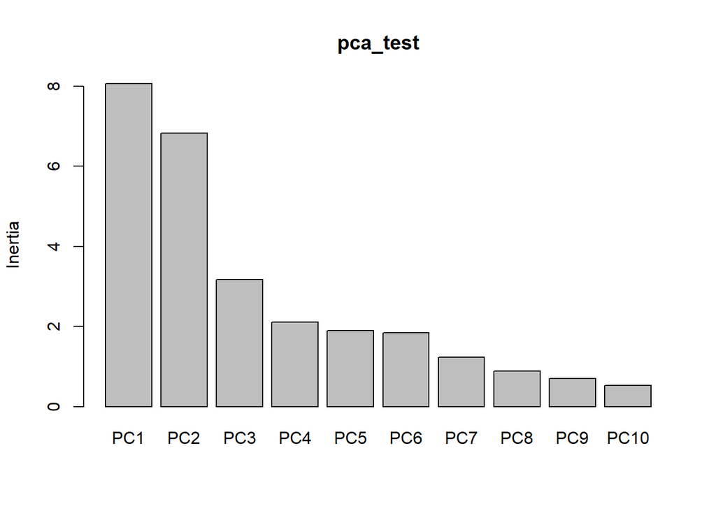

```r
# pca
pca_test<-prcomp(landscape_z, scale=FALSE)
# loadings can be accessed with $rotation
#pca_test$rotation # pca loading value used in linear equation to calculate score
#pca_test$x # pca scores
# test signifciance of eigen values a different way
#ordi.monte(data4,ord='pca',dim=3)
#ordi.scree(pca_test,ord='pca')
screeplot(pca_test)
```

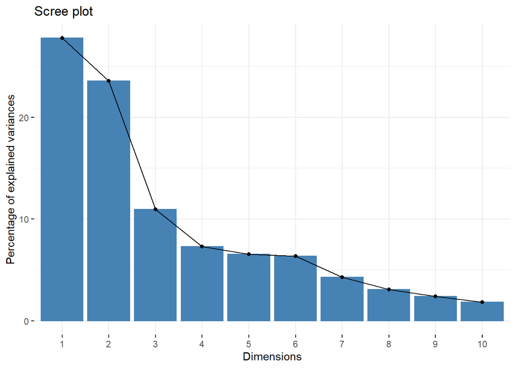

```r
fviz_eig(pca_test)
```

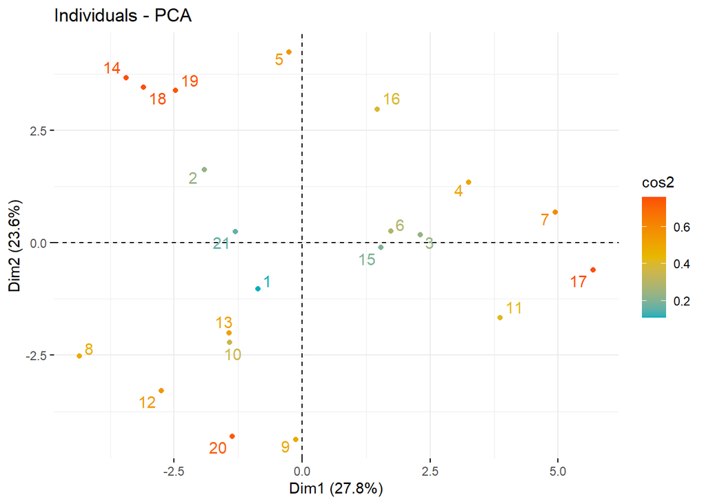

```r
fviz_pca_ind(pca_test,
             col.ind = "cos2", # Color by the quality of representation
             gradient.cols = c("#00AFBB", "#E7B800", "#FC4E07"),
             repel = TRUE     # Avoid text overlapping
             )
```

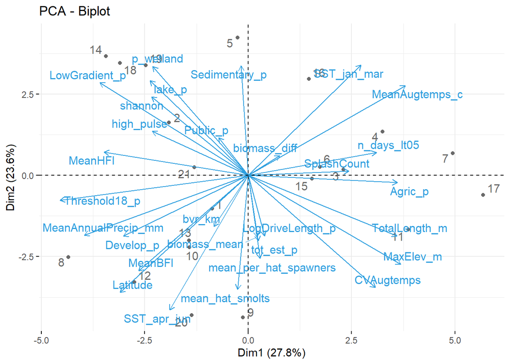

```r
fviz_pca_biplot(pca_test, repel = TRUE,
                col.var = "#2E9FDF", # Variables color
                col.ind = "#696969"  # Individuals color
                )
```

```r
eig.val <- get_eigenvalue(pca_test)
eig.val
```

```
##          eigenvalue variance.percent cumulative.variance.percent
## Dim.1  8.064073e+00     2.780715e+01                    27.80715
## Dim.2  6.832118e+00     2.355903e+01                    51.36618
## Dim.3  3.175061e+00     1.094849e+01                    62.31466
## Dim.4  2.114150e+00     7.290171e+00                    69.60483
## Dim.5  1.895432e+00     6.535974e+00                    76.14081
## Dim.6  1.840887e+00     6.347886e+00                    82.48869
## Dim.7  1.235942e+00     4.261868e+00                    86.75056
## Dim.8  8.874591e-01     3.060204e+00                    89.81077
## Dim.9  6.975091e-01     2.405204e+00                    92.21597
## Dim.10 5.321254e-01     1.834915e+00                    94.05088
## Dim.11 4.118615e-01     1.420212e+00                    95.47110
## Dim.12 3.556115e-01     1.226247e+00                    96.69734
## Dim.13 2.343356e-01     8.080540e-01                    97.50540
## Dim.14 2.287205e-01     7.886914e-01                    98.29409
## Dim.15 1.412434e-01     4.870461e-01                    98.78113
## Dim.16 1.296716e-01     4.471435e-01                    99.22828
## Dim.17 9.684300e-02     3.339414e-01                    99.56222
## Dim.18 8.325209e-02     2.870762e-01                    99.84930
## Dim.19 2.724555e-02     9.395018e-02                    99.94325
## Dim.20 1.645871e-02     5.675418e-02                   100.00000
## Dim.21 8.480672e-32     2.924370e-31                   100.00000
```

```r
get_pca_var(pca_test)
```

```
## Principal Component Analysis Results for variables
##  ===================================================
##   Name       Description
## 1 "$coord"   "Coordinates for the variables"
## 2 "$cor"     "Correlations between variables and dimensions"
## 3 "$cos2"    "Cos2 for the variables"
## 4 "$contrib" "contributions of the variables"
```

```r
res.var <- get_pca_var(pca_test)
res.var$contrib        # Contributions to the PCs
```

```
##                             Dim.1       Dim.2       Dim.3        Dim.4
## TotalLength_m          6.44436273  2.03372436  1.12037733 7.464465e-01
## MaxElev_m              6.75576453  4.38416009  0.04589889 7.037140e-01
## MeanAnnualPrecip_mm    7.81461757  1.98316860  0.01326214 2.288822e+00
## MeanBFI                3.48097791  5.04312909  4.49265182 4.839491e+00
## MeanAugtemps_c         7.18255615  4.47662491  0.31972944 2.659830e-02
## CVAugtemps             4.70101308  6.99724917  0.43367523 2.955947e-01
## Threshold18_p         10.27651367  0.34068701  0.02195856 1.524296e-01
## Sedimentary_p          0.01509027  6.66612099  1.82588192 7.524005e+00
## MeanHFI                6.03587025  0.30265103  2.85107931 7.270773e+00
## Public_p               0.25263606  0.79054079 19.61575474 7.499017e-02
## Latitude               4.76807649  7.63628946  0.48278980 2.141835e-01
## Develop_p              4.53808750  2.04899306 10.71709730 8.701402e-01
## Agric_p                6.45819732  0.02843273  0.94031427 7.959527e+00
## SplashCount            2.93573817  0.01077859  7.57989411 7.526465e+00
## biomass_diff           0.28941012  0.21852156  8.19530470 3.049248e+00
## biomass_mean           0.02275735  2.11982825 13.20491764 4.680803e+00
## bvr_km                 0.34856176  1.45080982  2.81812705 1.110593e-01
## mean_hat_smolts        0.03241846  7.21709416  1.22312439 2.353397e-04
## mean_per_hat_spawners  0.03959884  3.83024534  4.18475788 1.820770e-01
## high_pulse             2.67492537  1.07181160  4.90849067 1.731118e+01
## n_days_lt05            4.77022000  0.29332751  0.34214915 5.044452e+00
## shannon                2.70779583  3.44424705  0.14144426 2.558774e+00
## SST_apr_jun            1.79446631 10.06645881  0.11652981 1.658234e+00
## SST_jan_mar            3.69827054  6.77197581  3.06037882 1.201530e+00
## lake_p                 2.80272744  4.98998581  0.58707579 8.093191e+00
## tot_est_p              0.02931022  2.38063423  1.89234891 5.278254e+00
## LowGradient_p          6.40034571  4.77144244  1.01775794 1.310980e-05
## LogDriveLength_p       0.07937167  2.02600159  7.37334943 6.862515e+00
## p_wetland              2.65031869  6.60506616  0.47387870 3.475250e+00
##                              Dim.5       Dim.6       Dim.7        Dim.8
## TotalLength_m          8.489721019  4.44527339  0.01206884  1.108654224
## MaxElev_m              0.027105617  0.03853184  0.30969384  0.204885857
## MeanAnnualPrecip_mm    0.878343324  2.04458445  0.21279395  4.400479965
## MeanBFI                0.861078203  1.07444811  0.75669170  0.721893408
## MeanAugtemps_c         0.003163947  0.98192800  0.66719546  0.004453809
## CVAugtemps             0.552993485  0.11828873  0.51801638  0.741599191
## Threshold18_p          0.063620530  3.62049556  0.01607334  0.243690668
## Sedimentary_p          0.204992488  8.35439149  0.53238184  0.391655041
## MeanHFI                6.874027535  1.11829208  0.14429880  3.470925199
```

[output cut: 125 more lines]

```
## biomass_diff           3.52302352
## biomass_mean           4.75288669
## bvr_km                 0.15610517
## mean_hat_smolts        0.14070841
## mean_per_hat_spawners  0.01263927
## high_pulse             1.77845063
## n_days_lt05            0.36775922
## shannon                1.59840914
## SST_apr_jun            0.10609154
## SST_jan_mar            0.40094674
## lake_p                 2.38236132
## tot_est_p              0.12410485
## LowGradient_p          9.96004325
## LogDriveLength_p       0.58992941
## p_wetland              0.07894535
```

```r
#res.var$coord          # Coordinates
#res.var$cos2
```

## Variable loadings

- The eigen vec function outputs the weights of the variables in the linear equations that define the principal components.
- “The structure coefficients are simple linear correlation coefficients between the original variables and the principal components. In contrast to the eigenvector coefficients, the structure coefficients are correlations and directly measure the strength of the linear relationship between each variable and each principal component.”
- “Final communalities are the sum of the squared structure correlations and represent the percentage of a variable’s variance that is linearly account for by the retained principal components.”

```r
# eigen vectors
# weights used in the principal component = pca_test$rotation
# pca.eigenvec(pca_test,dim=3,digits=3,cutoff=.20) #
# # structure coefficients
# pca.structure(pca_test,landscape_z,dim=3,cutoff=.10) #
# # variance accounted for in total by retained principal components by adding up all squared structure coefficients of retained principal components
# pca.communality(pca_test,landscape_z,dim=3)
```

```r
# library(ggbiplot)
# ggbiplot::ggbiplot(pca_test)
```

## Biplot of PCA.

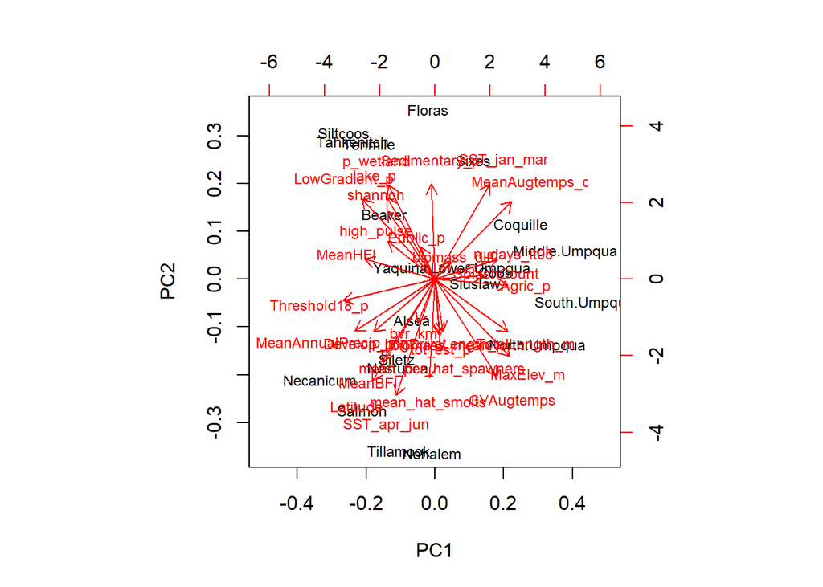

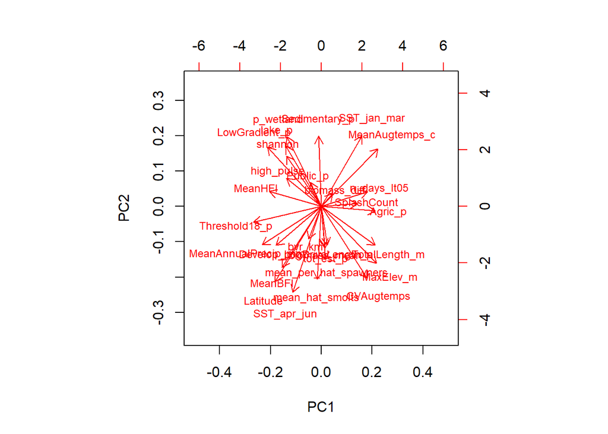

## biplot loadings >0.2 PC2

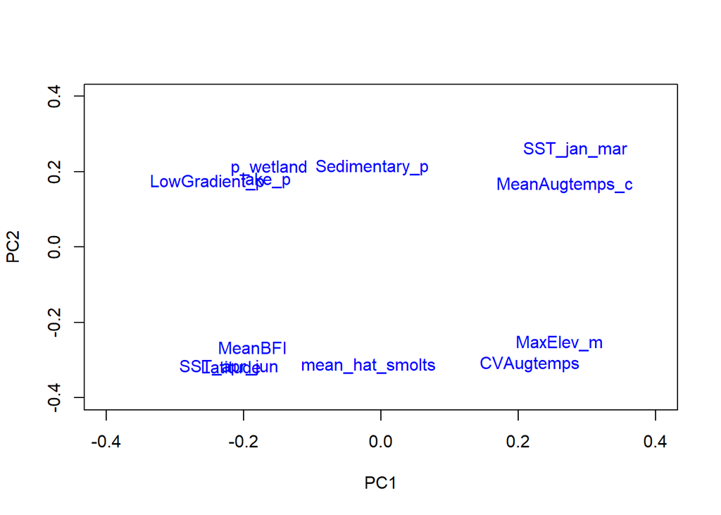

```r
plot(PC2~PC1, data=loadings_20p, type='n', xlim=c(-0.4, 0.4), ylim=c(-0.4, 0.4))
text(loadings_20p$PC1,loadings_20p$PC2,label=row.names(loadings_20p),col='blue', pos=c(1,1,1,1,1,1,1,2,4,1 ))
```

## biplot loadings >0.2 on PC2 or PC3

## Biplot of with subset of variables that have > 0.2 loadings weight on PC1 or PC2.

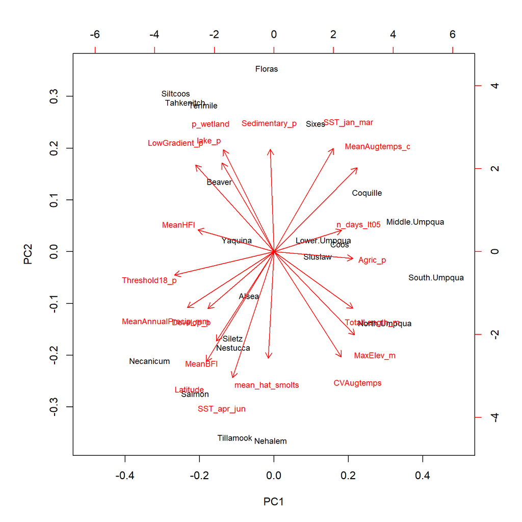

## Biplot of with subset of variables that have > 0.2 loadings weight on PC2 or PC3.

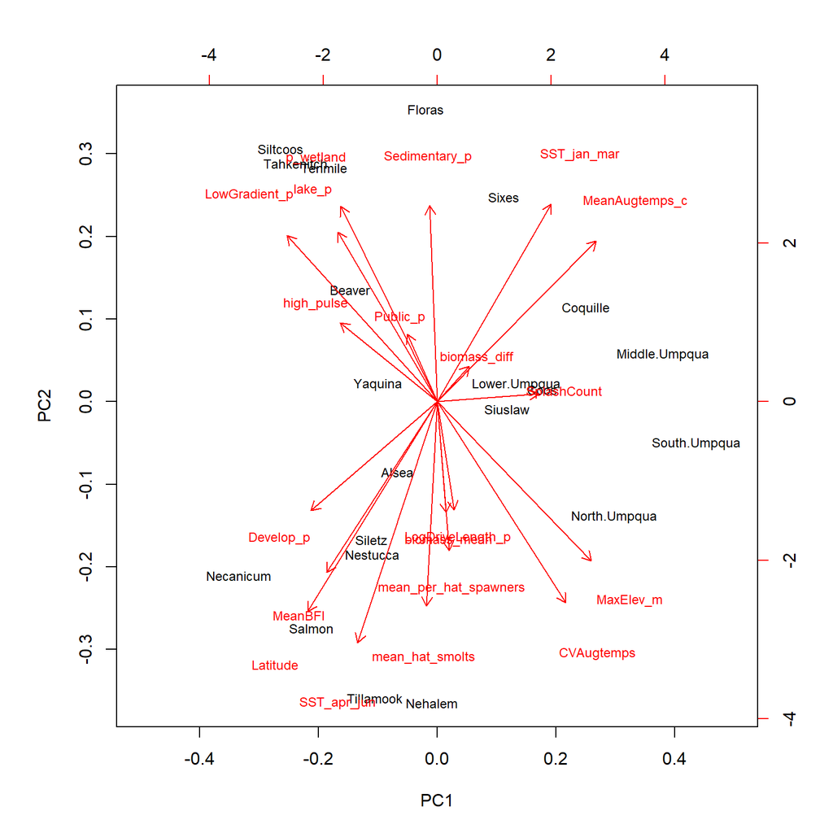

loadings_20p_PC1

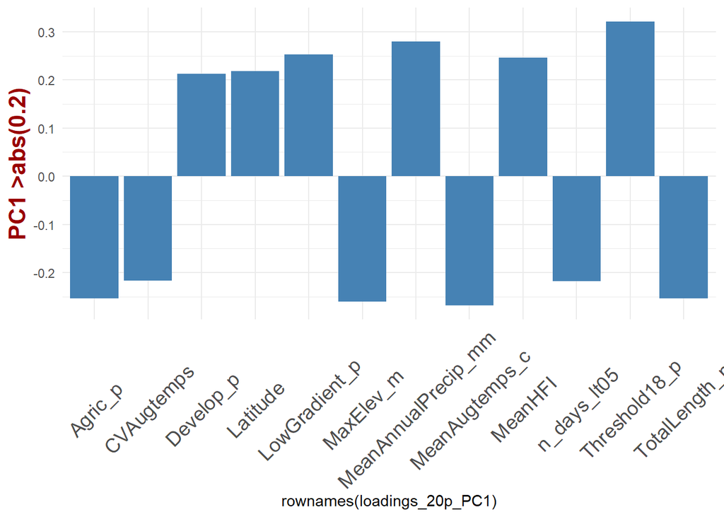

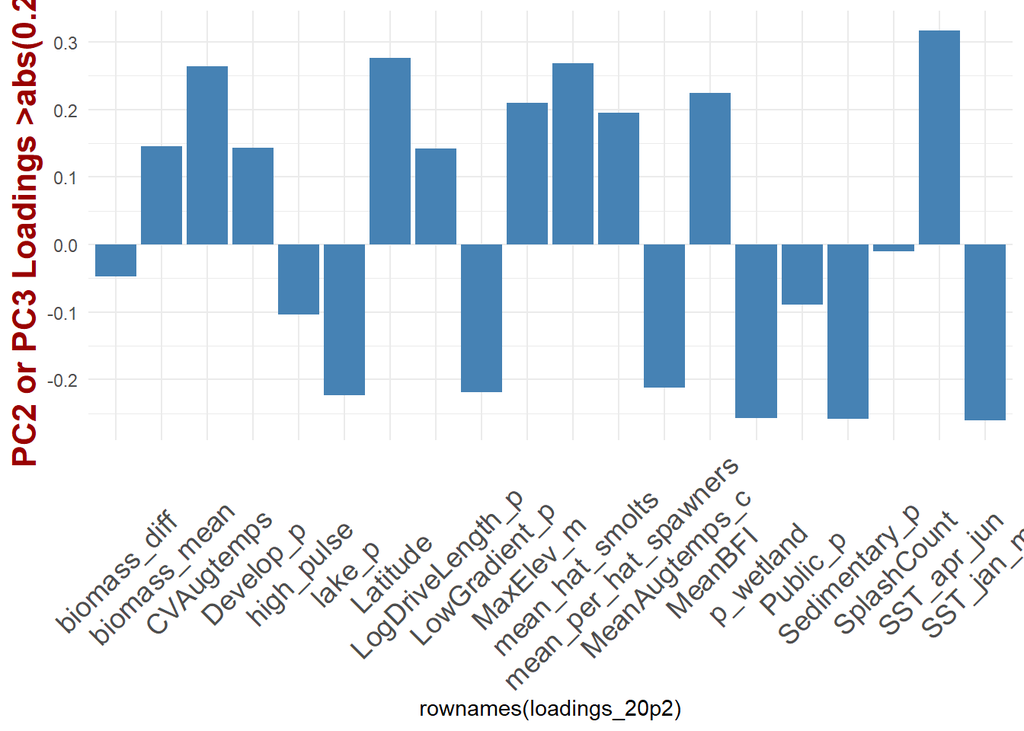

## Barplot including variables with loadings on PC2 > 0.2

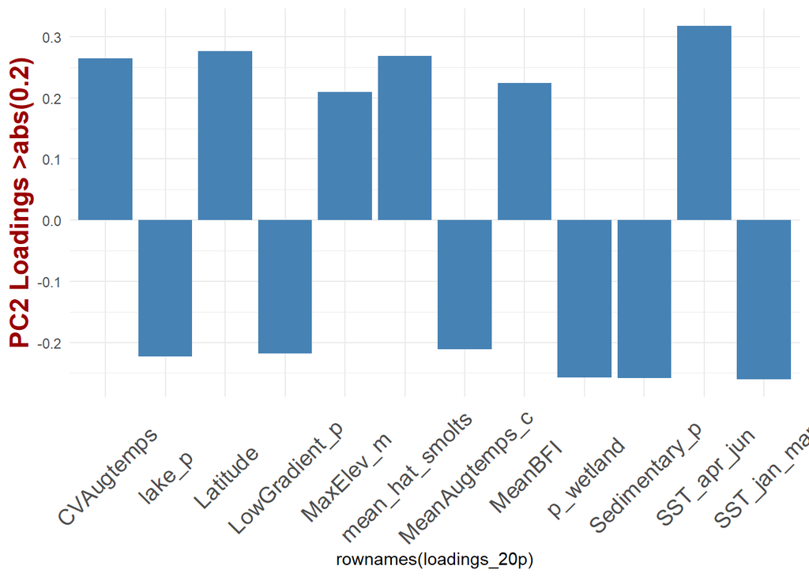

## Barplot including variables with loadings on PC3 > 0.2

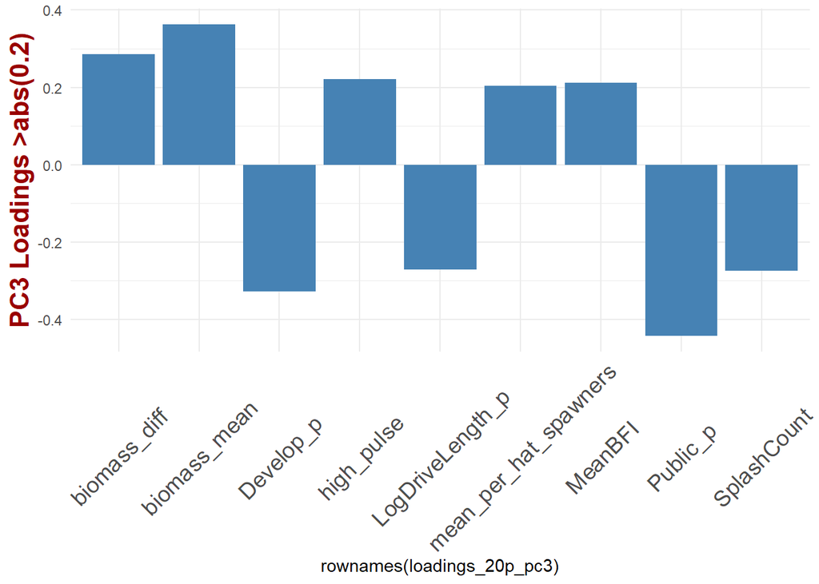

Convert principal components to scores for each watershed and join tables with CV, DD,with watershed characteristics, and PCA scores.

### Test for correlations again between significant PCA components with CV

| Principal component | CVcurrent |
| --- | --- |
| PC1 | 0.0233766233766234 |
| PC2 | 0.505194805194805 |
| PC3 | 0.0155844155844156 |

### Test for correlations again between significant PCA components with DD

| Principal component | DD |
| --- | --- |
| PC1 | -0.412987012987013 |
| PC2 | 0.524675324675325 |
| PC3 | -0.294805194805195 |

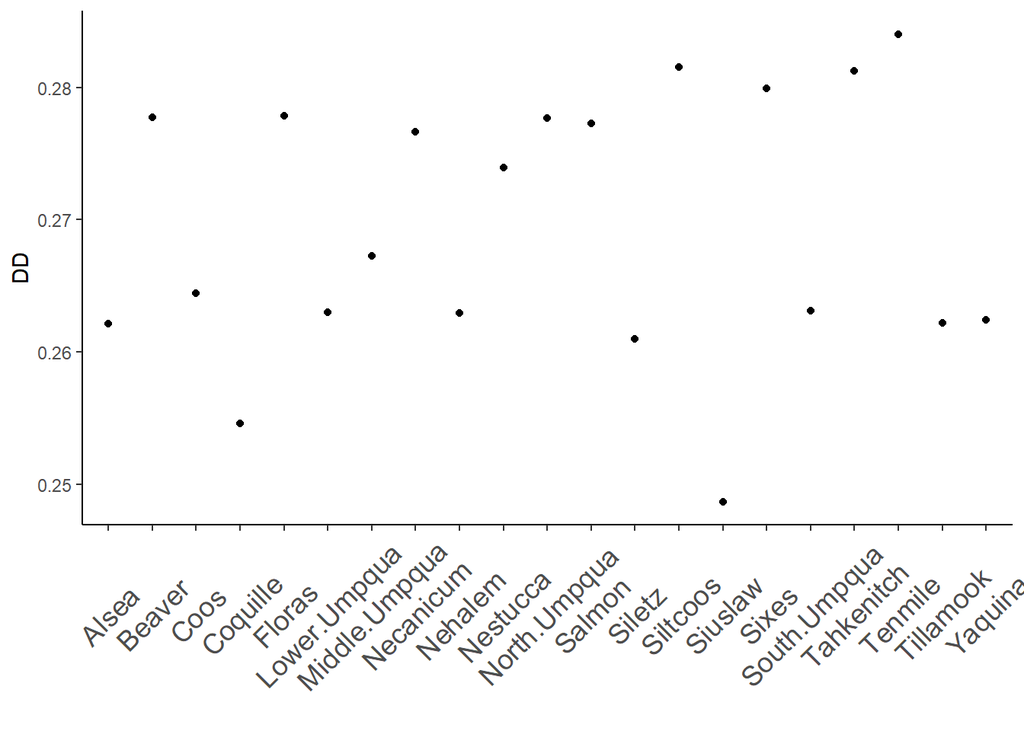

```r
ggplot(metrics, aes(x=pops_names, y = DD))+
  geom_point()+
  theme_classic()+
  theme(axis.text.x  = element_text(angle=45, vjust=0.5, size=14))+
  xlab(" ")
```

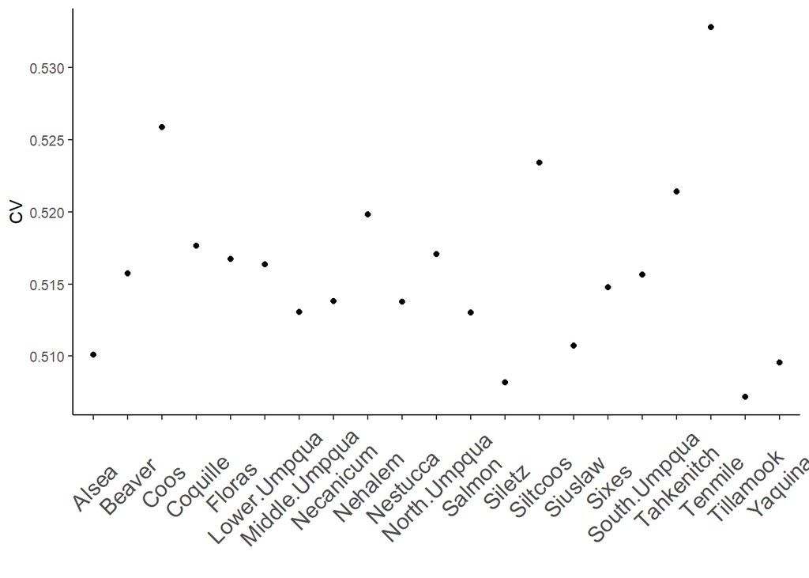

```r
ggplot(metrics, aes(x=pops_names, y = CVCurrent_LOO_V))+
  geom_point()+
  theme_classic()+
  theme(axis.text.x  = element_text(angle=45, vjust=0.5, size=14))+
  xlab(" ")+
  ylab("CV")
```

## Plots of Principal components with portfolio metrics.

Plots of landscape metrics with high structure coefficients on PC2 (>0.2).